# Symptoms - scheduler experiment

Carlos Granell, [SyMptOMS team](http://geotec.uji.es/projects/SyMptOMS/), [GEOTEC research group](http://geotec.uji.es/)

17/4/2020 (updated 02 junio, 2020)

This document analyses the self-developed scheduler component in Android-based mobile devices as part of the [SyMptOMS project](http://geotec.uji.es/projects/SyMptOMS/).

## Reproduce notebook

To create the PDF of the computational notebook you can run the following commands in a new R session. If you have problems rendering the PDF you can execute each chunk independently in [RStudio](https://rstudio.com/products/rstudio/).

This document does not install the required R packages by default. You can run the script `install.R` to install all required dependencies on a new R installation, or use `install.packages(..)` to install missing R packages.

The plots and tables use the packages [`ggplot2`](http://ggplot2.tidyverse.org/), [`knitr::kable()`](https://yihui.name/knitr/) and [`kableExtra`](https://cran.r-project.org/package=kableExtra).

Required libraries and runtime environment description are as follows.

```r
library(tidyverse)
library(kableExtra)
library(here)
# library(googledrive)
library(lubridate)
library(stringr)
library(scales)
# library(plotly)
library(grid)
library(gridBase)
library(gridExtra)
library(egg)
```

## Data download

Log files are stored in shared gdrvie folder. This notebook downloads them locally in the folder `data-raw`.

Table. List of raw data files.

| experiment | gsheets_name | gsheets_link |
| --- | --- | --- |
| #1 | AD_BQ.csv | https://drive.google.com/open?id=1fP9r0S8ORa689yHRtfCtYQothLuGcCw3 |
| #1 | AD_NV.csv | https://drive.google.com/open?id=1l-vnaT-Smy0SegArIz5A108-IQ2_jmVV |
| #1 | AD_A1.csv | https://drive.google.com/open?id=1gzk1ezN5t5yBv2RnbznUqvalDx97eu3o |
| #1 | BA_H9.csv | https://drive.google.com/open?id=1BLXO4Rvz6ppWFJe5oN9Y0hKh__ypofxk |
| #1 | BA_MO.csv | https://drive.google.com/open?id=1RizGjKR8QLOdJna7qGPP7dYX9WWAysO4 |
| #2 | BA_BQ.csv | https://drive.google.com/open?id=1rfaooLZ0Up0gNx1SCA92TV1JFxcLU0sk |
| #2 | BA_NV.csv | https://drive.google.com/open?id=1_KIXX5FGXv7MO37QbUDnd_KGqiGihiMI |
| #2 | BA_A1.csv | https://drive.google.com/open?id=1LezrtyB9i4K7cQsmI78E0v_KaOyhZcXI |
| #2 | AD_H9.csv | https://drive.google.com/open?id=1ISjsfSLZt6n9miryQtDr-tsZV9bfbCDT |
| #2 | AD_MO.csv | https://drive.google.com/open?id=1bx2RVNz05qVKGr-32GI-ZIOKQWlqKBPz |

## Data preparation

Raw data files are cleaned and merged together into a single file stored in the folder `data`. New fields such as dates breakdown are computed too.

**Key Variables**:

- quantitative (interval)
  - `plan_date` (*datetime*): task planning time.
  - `exec_date` (*datetime*): task execution time.
- quantitative (ratio)
  - `delay` (*numeric*): execution delay in seconds ((`exec_date` - `plan_date`) - 60).
- categorital (ordinal)
  - `battery`(*numeric*): battery level
- categorical (nominal)
  - `device_id`/`device_name`: device identifier/name
  - `exp_id`: experiment identifier
  - `scheduler`: scheduler type

## Exploratory analysis

### Summary statistics

Table. Descriptive statistics of data distribution and centrality per scheduler/device.

| # exp | Type scheduler | Device | # records | Start | End | Min | Bottom whisker | 1st Qu. | Median | Mean | 3rd Qu. | Top whisker | Max |
| --- | --- | --- | --- | --- | --- | --- | --- | --- | --- | --- | --- | --- | --- |
| #1 | Advanced | BQ Aquaris V | 21391 | 2020-03-30 12:15:03 | 2020-04-14 13:07:57 | -48.591 | 0.235 | 0.546 | 0.651 | 0.769 | 0.754 | 1.065 | 61.204 |
|  |  | Nvidia Shield Tablet | 21453 | 2020-03-30 12:15:03 | 2020-04-14 13:08:14 | -52.811 | -0.882 | 0.052 | 0.241 | 0.673 | 1.043 | 2.518 | 103.849 |
|  |  | Xiaomi Mi A1 | 21465 | 2020-03-30 12:23:27 | 2020-04-14 13:07:50 | -60.925 | -0.840 | 0.088 | 0.269 | 0.493 | 0.838 | 1.945 | 68.872 |
|  | Basic | Honor 9 | 21574 | 2020-03-30 12:00:03 | 2020-04-14 13:01:35 | -0.824 | -0.094 | 0.068 | 0.087 | 0.311 | 0.187 | 0.364 | 295.963 |
|  |  | Motorola Moto G | 21619 | 2020-03-30 12:00:07 | 2020-04-14 13:01:16 | -0.183 | -0.183 | 0.062 | 0.100 | 0.875 | 0.289 | 0.629 | 60.896 |
| #2 | Advanced | Honor 9 | 19377 | 2020-04-15 11:00:02 | 2020-04-29 12:59:15 | -59.535 | -0.423 | 0.167 | 0.225 | 0.591 | 0.842 | 1.853 | 93.032 |
|  |  | Motorola Moto G | 19735 | 2020-04-16 12:09:53 | 2020-04-30 12:58:44 | -30.166 | -0.212 | 0.117 | 0.167 | 2.092 | 0.782 | 1.778 | 126.487 |
|  | Basic | BQ Aquaris V | 20146 | 2020-04-15 11:16:26 | 2020-04-29 13:00:20 | -0.111 | 0.065 | 0.280 | 0.297 | 0.390 | 0.424 | 0.639 | 34.412 |
|  |  | Nvidia Shield Tablet | 3528 | 2020-04-15 11:16:18 | 2020-04-17 22:27:06 | -0.871 | -0.871 | 0.021 | 0.122 | 0.431 | 1.007 | 2.085 | 4.841 |
|  |  | Xiaomi Mi A1 | 10832 | 2020-04-15 11:16:23 | 2020-04-23 00:52:00 | -0.905 | -0.661 | 0.066 | 0.302 | 0.405 | 0.614 | 1.416 | 108.035 |

**Observations on the above table** :

- 181.120 records in total.
- 50.6% (91.582/181.120) is the interquartile range or [IQR](https://en.wikipedia.org/wiki/Interquartile_range), i.e. the middle 50% of the data.
- 39.6% (71.769/181.120) represent the *reasonable* extremes of the data, i.e. these whisker values are the minimum and maximum values that do not exceed 1.5 × IQR.
- 9.8% (17.769/181.120) are outliers, i.e. values beyond the top and bottom whiskers.
- `Nvidia Shield Tablet` has stopped triggering alarms on **2020-04-17 22:27:06** when running the basic scheduler. Since there’s no *watchdog* in the basic version, this device is not going to trigger alarms anymore. Died!
- `Xiaomi Mi A1` has stopped triggering alarms on **2020-04-23 00:52:00** when running the basic scheduler. An explanation may be that Huawei/Honor smartphones on Android 9+ have a Launch Records where the OS records how much times an app has been launched by itself, so the OS has the possibility to detect this kind of apps. In these smartphones, Huawei also introduced a new task killer (Power Genius) which kills everything that is not whitelisted by Huawei, and does not give users any configuration options. Therefore, the Power Genius uses the information from the Launch Records to kill the scheduled alarms

### Q1: Which one of the analysed schedulers is more reliable? (Distribution of outliers)

In mental health interventions, to have a predictable execution of planned actions is mostly preferred which means that notifications and/or alerts are delivered to patients at the right moment. It is inconceivable, for example, that a patient gets a notification (e.g. action, psyco content, etc.) 1 minute later than the event (e..g passing nearby a gambling hall) that triggered it; the patient could be dozens of meters away from the place of interest or, even worse, walked into that “no-desirable” place. Therefore, closing the “temporal” gap between the triggered event and the action is critical (time matters), especially because time and space/place must be in synchrony in mental health EMIs. If these two dimensions are not in synchrony, the intervetion becomes far less effective.

Table. Outliers per scheduler/device.

| Device | # exp | Type scheduler | # outliers | # outliers positive | # outliers negative |
| --- | --- | --- | --- | --- | --- |
| BQ Aquaris V | #1 | Advanced | 1646 | 925 | 721 |
| BQ Aquaris V | #2 | Basic | 2996 | 2499 | 497 |
| Honor 9 | #2 | Advanced | 307 | 209 | 98 |
| Honor 9 | #1 | Basic | 5033 | 5018 | 15 |
| Motorola Moto G | #2 | Advanced | 2861 | 2852 | 9 |
| Motorola Moto G | #1 | Basic | 4377 | 4377 | NA |
| Nvidia Shield Tablet | #1 | Advanced | 294 | 285 | 9 |
| Nvidia Shield Tablet | #2 | Basic | 3 | 3 | NA |
| Xiaomi Mi A1 | #1 | Advanced | 224 | 121 | 103 |
| Xiaomi Mi A1 | #2 | Basic | 28 | 27 | 1 |

| scheduler | n_total |
| --- | --- |
| Advanced | 5332 |
| Basic | 12437 |

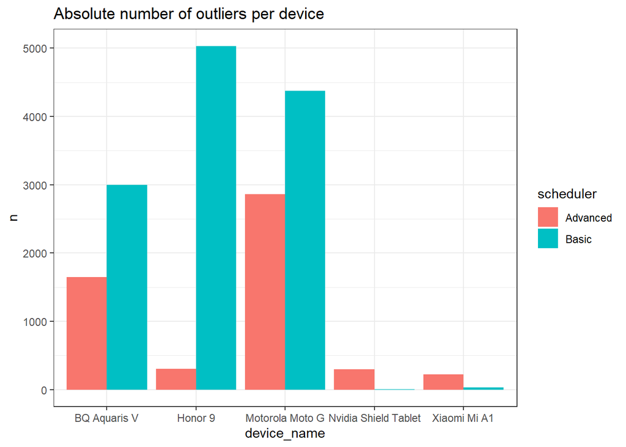

#### BQ Aquaris V

- Number of outliers: 4642
- Number of outliers (top range): 3424 - 73.8% (3.424/4.642).
- Number of outliers (bottom range): 1218 - 26.2% (1.218/4.642).

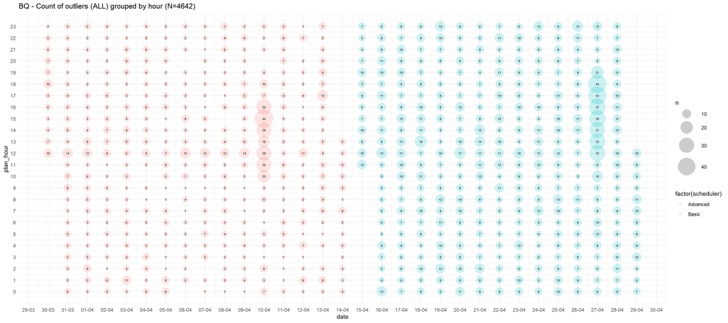

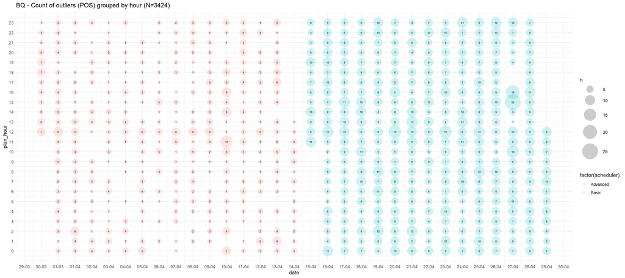

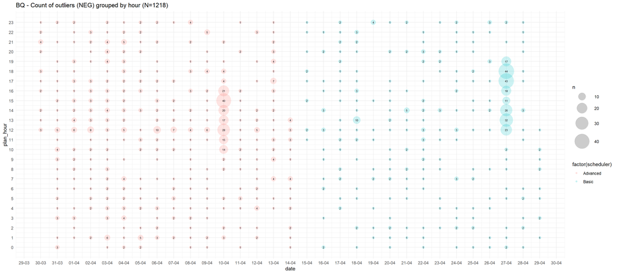

#### Nvidia Shield Tablet

- Number of outliers: 297
- Number of outliers (top range): 288 - 97% (288/297).
- Number of outliers (bottom range): 9 - 3% (9/297).

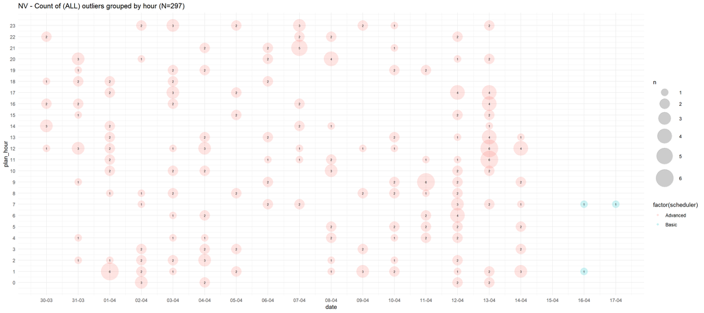

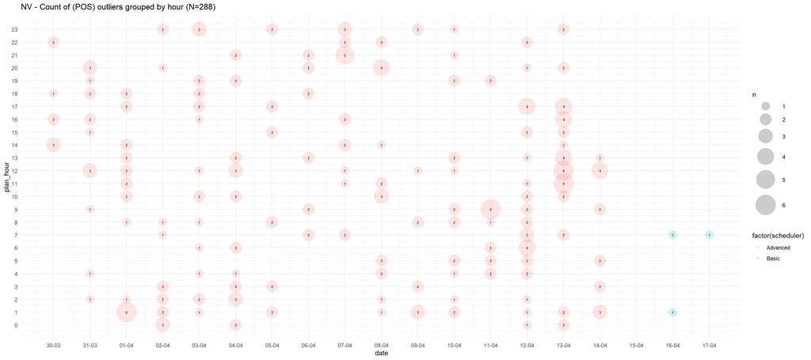

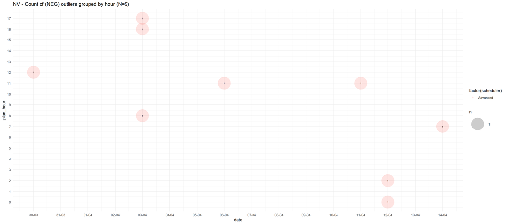

#### Xiaomi Mi A1

- Number of outliers: 252
- Number of outliers (top range): 148 - 58.7% (148/252).
- Number of outliers (bottom range): 104 - 41.3% (104/252).

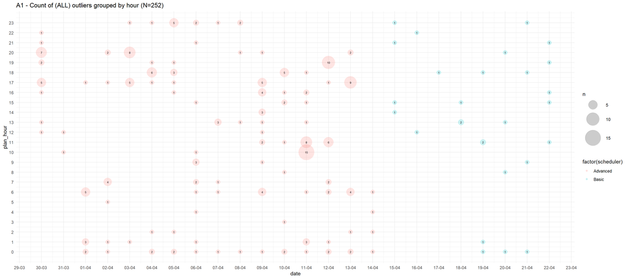

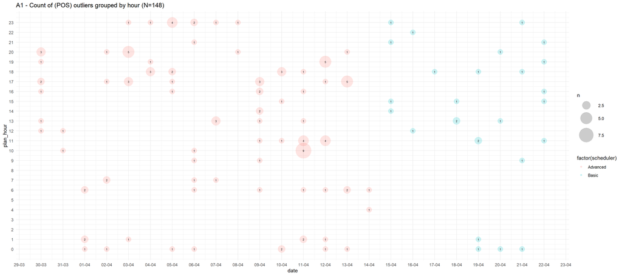

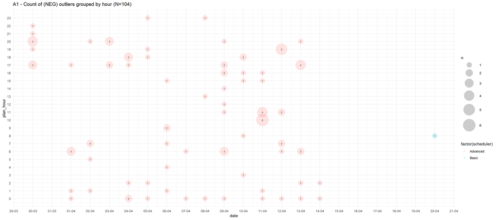

#### Honor 9

- Number of outliers: 5340
- Number of outliers (top range): 5227 - 97.9% (5.227/5.340).
- Number of outliers (bottom range): 113 - 2.1% (113/5.340).

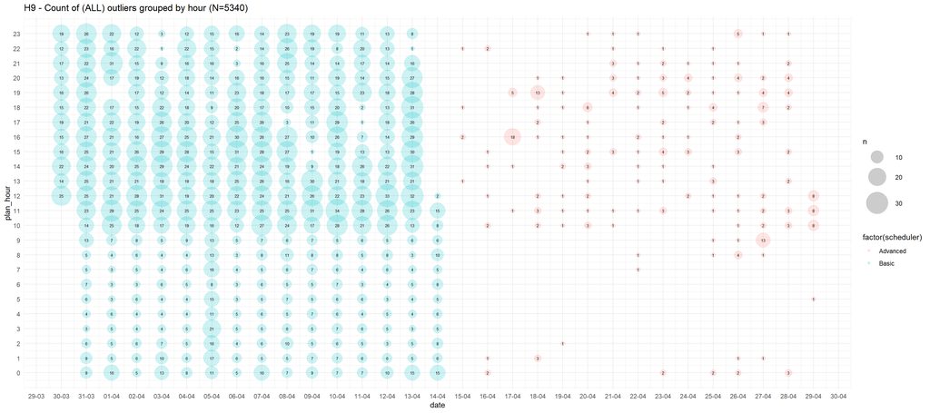

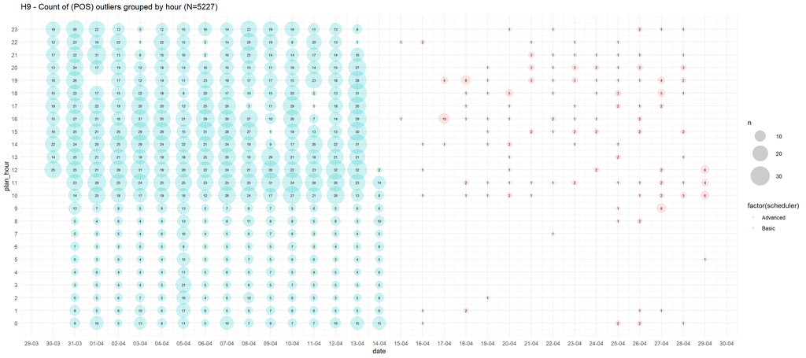

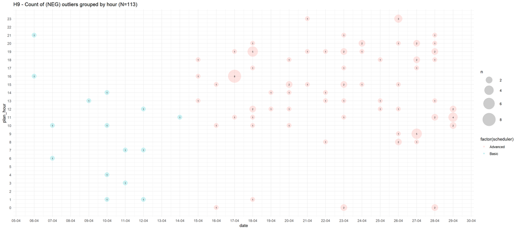

#### Motorola Moto G

- Number of outliers: 7238
- Number of outliers (top range): 7229 - 99.9% (7.229/7.238).
- Number of outliers (bottom range): 9 - 0.1% (9/7.238).

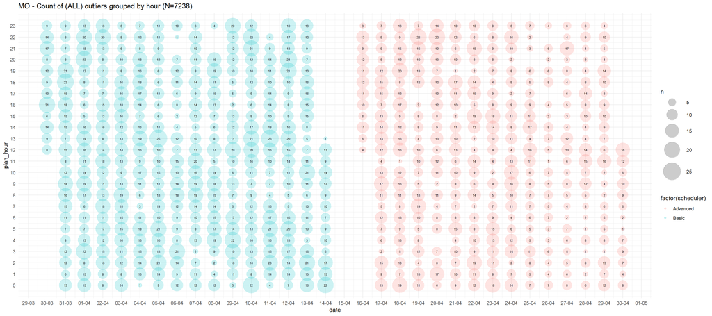

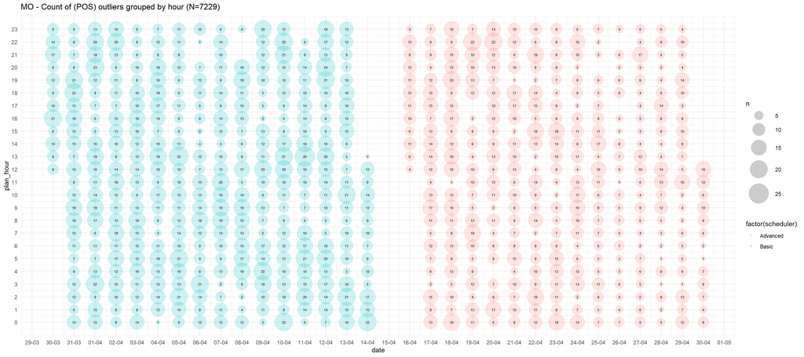

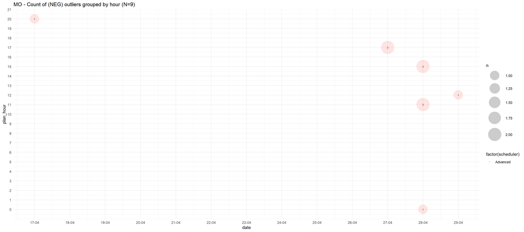

#### Advanced scheduler vs basic scheduler

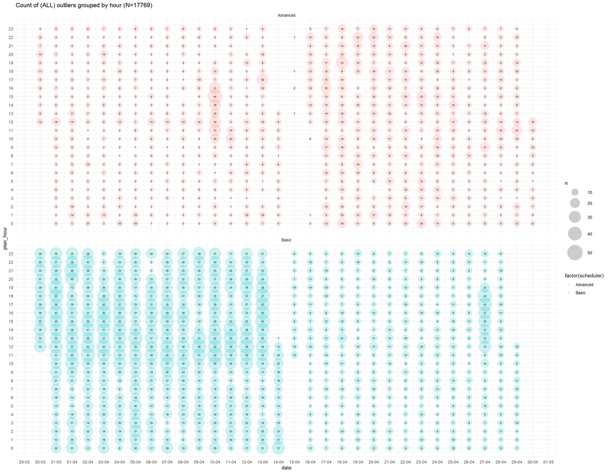

#### Centrality statistics of outliers

| scheduler | device_name | mean | median |
| --- | --- | --- | --- |
| Advanced | BQ Aquaris V | 2.1539143 | 1.0830 |
| Advanced | Honor 9 | 9.5330423 | 3.2580 |
| Advanced | Motorola Moto G | 12.7074159 | 9.0550 |
| Advanced | Nvidia Shield Tablet | 13.6128095 | 10.9860 |
| Advanced | Xiaomi Mi A1 | 5.0634241 | 8.5705 |
| Basic | BQ Aquaris V | 0.7612009 | 0.9000 |
| Basic | Honor 9 | 1.0521444 | 1.0180 |
| Basic | Motorola Moto G | 3.8990078 | 1.5000 |
| Basic | Nvidia Shield Tablet | 3.4696667 | 2.8620 |
| Basic | Xiaomi Mi A1 | 11.1098214 | 1.6820 |

| scheduler | mean | median |
| --- | --- | --- |
| Advanced | 8.995551 | 4.9965 |
| Basic | 2.007192 | 1.0030 |

#### Concluding remarks (Q1)

In response to the question *Which one of the two schedulers is more reliable?*, we observe the following statements based on the metric `delay`.

Feasibility on the execution of schedulers:

- Basic scheduler stopped running in 2 (out of 5) devices.
- Advanced scheduler completed the experiments on all devices (Note: to clarify issue with Honor 9)

Number of outliers:

- The number of outliers in the experiments with the basic scheduler is more than double that of the experiments with the advanced scheduler. Therefore,the advanced scheduler beats the basic one in terms of number of outliers.
- `Honor 9` shows a remarkly difference between the two schedulers. This is importnat because this device was used regularly while runing the experiments, demonstrted by the distinct distribution of outliers atnigthtime againts daytime.
- Majority of outliers are positive (beyond top whisker). Negative values should be interpreted as wrong values due to planned timestamps mistakenly recorded during data collection.

Frequency of outliers:

- It is not observed a temporal pattern regarding the frequency of outliers for devices used exclusively for the experiments. Outliers are generally evenly distributed over time

Centrality measurements of outliers:

### Q2 (Ongoing in another notebook. Will be integrated shortly here)

#### Concluding remarks (Q3)

### Q4: Which one of the analysed schedulers loses fewer alarm executions?

#### Concluding remarks (Q4)

## DISCARD TEXT/CODE BEYOND THIS LINE

### Boxplots

Distribution of data based on a five number summary (“minimum”, first quartile (Q1), median, third quartile (Q3), and “maximum”).